# Coca-Cola Consolidated, Inc.

2025 Annual Report · Data Visualization Analysis · BANA 4137

Tyler Jones

Spring 2026

```r
# Install any missing packages:
# install.packages(c("ggplot2","dplyr","tidyr","scales","ggtext","patchwork","gt"))

library(ggplot2)
library(dplyr)
library(tidyr)
library(scales)
library(ggtext)
library(patchwork)
library(knitr)
library(gt)

# ── Brand palette ────────────────────────────────────────────────
COKE_RED  <- "#d01f2e"
COKE_DKRD <- "#8b0000"
NAVY      <- "#1d3557"
GRAY      <- "#6b7280"
LGRAY     <- "#e5e7eb"
DKBG      <- "#1a1a2e"
GREEN     <- "#15803d"

# ── Reusable theme ───────────────────────────────────────────────
theme_coke <- function(base_size = 12) {
  theme_minimal(base_size = base_size) +
    theme(
      plot.title    = element_text(face = "bold", size = base_size + 2,
                                   color = DKBG, margin = margin(b = 4)),
      plot.subtitle = element_text(color = "#555555", size = base_size - 1,
                                   margin = margin(b = 12)),
      plot.caption  = element_text(color = "#999999", size = base_size - 3,
                                   margin = margin(t = 10)),
      panel.grid.minor   = element_blank(),
      panel.grid.major   = element_line(color = "#f0f1f5", linewidth = 0.5),
      axis.text          = element_text(color = "#555555"),
      axis.title         = element_text(color = "#666666", size = base_size - 1),
      plot.background    = element_rect(fill = "white", color = NA),
      panel.background   = element_rect(fill = "white", color = NA),
      legend.position    = "bottom",
      legend.title       = element_blank()
    )
}
```

## 1 · Dataset Description

The data for this project come directly from **Coca-Cola Consolidated’s 2025 Annual Report (Form 10-K)**, filed with the U.S. Securities and Exchange Commission for the fiscal year ended December 31, 2025. Coca-Cola Consolidated (Nasdaq: **COKE**) is the largest Coca-Cola bottler in the United States, distributing more than 300 brands and flavors to approximately 60 million consumers across 14 states and Washington D.C.

### Table 1 — Annual Financial Summary (2023–2025)

Each **row** represents one fiscal year. Each **column** is a financial metric extracted from the Consolidated Statements of Operations and Cash Flows. This table has **3 observations** and **9 variables**, all of which are numeric and continuous (Year treated as ordinal). There are **no missing values** — all figures are audited.

```r
fin_raw <- data.frame(
  Year       = c(2023,   2024,   2025),
  Net_Sales  = c(6653.9, 6899.7, 7228.1),
  COS        = c(4055.1, 4146.5, 4355.7),
  Gross_Prof = c(2598.7, 2753.2, 2872.4),
  SDA        = c(1764.3, 1832.8, 1921.7),
  Op_Income  = c(834.5,  920.4,  950.7),
  Net_Income = c(408.4,  633.1,  570.6),
  Op_CF      = c(810.7,  876.4,  931.9),
  CapEx      = c(282.3,  371.0,  312.3)
)

fin_raw |>
  gt() |>
  cols_label(
    Year       = "Year",
    Net_Sales  = "Net Sales",
    COS        = "Cost of Sales",
    Gross_Prof = "Gross Profit",
    SDA        = "SD&A Expenses",
    Op_Income  = "Op. Income",
    Net_Income = "Net Income",
    Op_CF      = "Op. Cash Flow",
    CapEx      = "CapEx"
  ) |>
  fmt_number(columns = -Year, decimals = 1) |>
  tab_spanner(label = "Income Statement",
              columns = c(Net_Sales, COS, Gross_Prof, SDA, Op_Income)) |>
  tab_spanner(label = "Cash Flow",  columns = c(Op_CF)) |>
  tab_spanner(label = "Investment", columns = c(CapEx)) |>
  tab_style(style = cell_text(weight = "bold"),
            locations = cells_body(rows = Year == 2025)) |>
  tab_style(style = cell_fill(color = "#fff8f8"),
            locations = cells_body(rows = Year == 2025)) |>
  tab_source_note("All figures in USD millions. Source: Coca-Cola Consolidated Form 10-K, FY 2025.") |>
  tab_options(
    table.border.top.color       = COKE_RED,
    table.border.top.width       = px(2),
    column_labels.border.bottom.color = "#333333",
    table.font.names             = "Segoe UI",
    table.font.size              = px(13)
  )
```

| Year | Income Statement Net Sales | Income Statement Cost of Sales | Income Statement Gross Profit | Income Statement SD&A Expenses | Income Statement Op. Income | Net Income | Cash Flow Op. Cash Flow | Investment CapEx |
| --- | --- | --- | --- | --- | --- | --- | --- | --- |
| 2023 | 6,653.9 | 4,055.1 | 2,598.7 | 1,764.3 | 834.5 | 408.4 | 810.7 | 282.3 |
| 2024 | 6,899.7 | 4,146.5 | 2,753.2 | 1,832.8 | 920.4 | 633.1 | 876.4 | 371.0 |
| 2025 | 7,228.1 | 4,355.7 | 2,872.4 | 1,921.7 | 950.7 | 570.6 | 931.9 | 312.3 |

All figures in USD millions. Source: Coca-Cola Consolidated Form 10-K, FY 2025.

### Descriptive Statistics — Table 1

The table below summarizes the range and central tendency of each financial metric across the three-year period. All variables are continuous and numeric; no transformations were applied.

```r
desc <- data.frame(
  Metric = c("Net Sales", "Cost of Sales", "Gross Profit",
             "SD&A Expenses", "Op. Income", "Net Income",
             "Op. Cash Flow", "CapEx"),
  Min    = c(6653.9, 4055.1, 2598.7, 1764.3, 834.5, 408.4, 810.7, 282.3),
  Max    = c(7228.1, 4355.7, 2872.4, 1921.7, 950.7, 633.1, 931.9, 371.0),
  Mean   = round(c(mean(c(6653.9,6899.7,7228.1)),
                   mean(c(4055.1,4146.5,4355.7)),
                   mean(c(2598.7,2753.2,2872.4)),
                   mean(c(1764.3,1832.8,1921.7)),
                   mean(c(834.5,920.4,950.7)),
                   mean(c(408.4,633.1,570.6)),
                   mean(c(810.7,876.4,931.9)),
                   mean(c(282.3,371.0,312.3))), 1),
  Chg3yr = c("+8.6%", "+7.4%", "+10.5%",
             "+8.9%", "+13.9%", "+39.7%",
             "+14.9%", "+10.6%"),
  stringsAsFactors = FALSE
)

desc |>
  gt() |>
  cols_label(
    Metric = "Metric",
    Min    = "Min ($M)",
    Max    = "Max ($M)",
    Mean   = "Mean ($M)",
    Chg3yr = "3-Yr Change"
  ) |>
  fmt_number(columns = c(Min, Max, Mean), decimals = 1) |>
  cols_align(align = "right", columns = c(Min, Max, Mean, Chg3yr)) |>
  cols_align(align = "left",  columns = Metric) |>
  tab_style(
    style = list(cell_fill(color = "#fff8f8"),
                 cell_text(color = COKE_RED, weight = "bold")),
    locations = cells_body(rows = Metric == "Net Income")
  ) |>
  tab_footnote(
    footnote = "Net Income's 3-year change is misleading due to large non-cash charges in 2023 and 2025; operating cash flow is a more stable performance proxy.",
    locations = cells_body(rows = Metric == "Net Income", columns = Chg3yr)
  ) |>
  tab_source_note("All figures in USD millions. n = 3 observations (FY 2023, 2024, 2025). No missing values.") |>
  tab_options(
    table.border.top.color = COKE_RED,
    table.border.top.width = px(2),
    table.font.names       = "Segoe UI",
    table.font.size        = px(13)
  )
```

| Metric | Min ($M) | Max ($M) | Mean ($M) | 3-Yr Change |
| --- | --- | --- | --- | --- |
| Net Sales | 6,653.9 | 7,228.1 | 6,927.2 | +8.6% |
| Cost of Sales | 4,055.1 | 4,355.7 | 4,185.8 | +7.4% |
| Gross Profit | 2,598.7 | 2,872.4 | 2,741.4 | +10.5% |
| SD&A Expenses | 1,764.3 | 1,921.7 | 1,839.6 | +8.9% |
| Op. Income | 834.5 | 950.7 | 901.9 | +13.9% |
| Net Income | 408.4 | 633.1 | 537.4 | <sup>1</sup> +39.7% |
| Op. Cash Flow | 810.7 | 931.9 | 873.0 | +14.9% |
| CapEx | 282.3 | 371.0 | 321.9 | +10.6% |

<sup>1</sup> Net Income's 3-year change is misleading due to large non-cash charges in 2023 and 2025; operating cash flow is a more stable performance proxy.  
All figures in USD millions. n = 3 observations (FY 2023, 2024, 2025). No missing values.

### Table 2 — Product Category Revenue & Volume (2024–2025)

```r
cat_raw <- data.frame(
  Category = rep(c("Sparkling Beverages", "Still Beverages",
                   "Sales to Other Bottlers", "Post-Mix & Other"), 2),
  Year     = c(rep(2024, 4), rep(2025, 4)),
  Revenue  = c(4106.1, 2227.2, 345.6, 220.8,
               4249.8, 2362.9, 383.7, 231.7),
  Volume   = c(266.7, 86.4, NA, NA, 266.7, 87.3, NA, NA),
  RevCase  = c(15.40, 25.77, NA, NA, 15.94, 27.07, NA, NA)
)

cat_raw |>
  gt(groupname_col = "Year") |>
  cols_label(
    Category = "Category",
    Year     = "Year",
    Revenue  = "Revenue ($M)",
    Volume   = "Volume (M cases)",
    RevCase  = "Revenue / Case ($)"
  ) |>
  fmt_number(columns = c(Revenue, Volume, RevCase), decimals = 2) |>
  sub_missing(columns = everything(), missing_text = "—") |>
  cols_align(align = "right",  columns = c(Revenue, Volume, RevCase)) |>
  cols_align(align = "left",   columns = Category) |>
  tab_style(
    style = cell_fill(color = "#f8fafc"),
    locations = cells_row_groups()
  ) |>
  tab_style(
    style = cell_text(weight = "bold"),
    locations = cells_row_groups()
  ) |>
  tab_source_note("Volume and Revenue/Case shown for bottle/can categories only. All figures in USD millions.") |>
  tab_options(
    table.border.top.color = COKE_RED,
    table.border.top.width = px(2),
    table.font.names       = "Segoe UI",
    table.font.size        = px(13)
  )
```

| Category | Revenue ($M) | Volume (M cases) | Revenue / Case ($) |
| --- | --- | --- | --- |
| 2024 |  |  |  |
| Sparkling Beverages | 4,106.10 | 266.70 | 15.40 |
| Still Beverages | 2,227.20 | 86.40 | 25.77 |
| Sales to Other Bottlers | 345.60 | — | — |
| Post-Mix & Other | 220.80 | — | — |
| 2025 |  |  |  |
| Sparkling Beverages | 4,249.80 | 266.70 | 15.94 |
| Still Beverages | 2,362.90 | 87.30 | 27.07 |
| Sales to Other Bottlers | 383.70 | — | — |
| Post-Mix & Other | 231.70 | — | — |

Volume and Revenue/Case shown for bottle/can categories only. All figures in USD millions.

## 2 · Question 1 — The Profit Paradox: How Did Net Income Fall in a Record Revenue Year?

In 2025, Coca-Cola Consolidated posted **record net sales** of $7.23 billion and **record operating income** of $950.7 million. Yet net income *fell* 9.9% — moving in the opposite direction from every other major financial metric. The waterfall (bridge) chart below walks from Operating Income to Net Income step by step, showing exactly where $380 million disappeared and which single item was responsible for 35% of that decline.

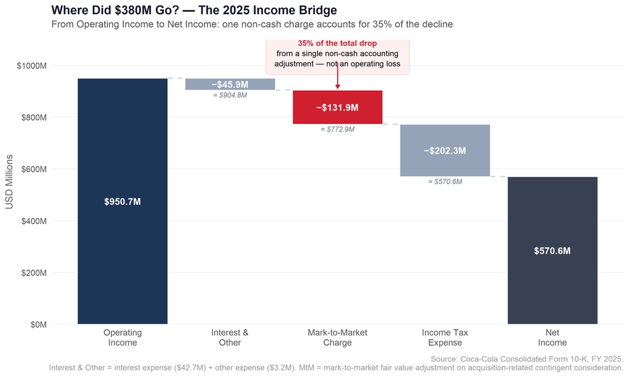

```r
# ── Waterfall bridge: Operating Income → Net Income (FY 2025) ─────
# Source: 10-K Consolidated Statements of Operations
#   Interest expense, net : $42.7M
#   Other expense, net    : $ 3.2M  → combined = $45.9M
#   MtM charge            : $131.9M
#   Income tax expense    : $202.3M
#   Net Income            : $570.6M  (check: 950.7-45.9-131.9-202.3 = 570.6 ✓)

wf <- data.frame(
  x     = 1:5,
  label = c("Operating\nIncome", "Interest &\nOther",
            "Mark-to-Market\nCharge", "Income Tax\nExpense", "Net\nIncome"),
  ymin  = c(  0.0, 904.8, 772.9, 570.6,   0.0),
  ymax  = c(950.7, 950.7, 904.8, 772.9, 570.6),
  type  = c("start", "neg", "highlight", "neg", "end"),
  amt   = c("$950.7M", "\u2212$45.9M", "\u2212$131.9M", "\u2212$202.3M", "$570.6M")
)

# Dashed connectors between bars (right edge of bar n → left edge of bar n+1)
connectors <- data.frame(
  x    = c(1.42, 2.42, 3.42, 4.42),
  xend = c(1.58, 2.58, 3.58, 4.58),
  y    = c(950.7, 904.8, 772.9, 570.6),
  yend = c(950.7, 904.8, 772.9, 570.6)
)

wf_colors <- c(
  "start"     = NAVY,
  "neg"       = "#94a3b8",
  "highlight" = COKE_RED,
  "end"       = "#374151"
)

ggplot(wf) +
  # ── Connector dashes ──
  geom_segment(data = connectors,
               aes(x = x, xend = xend, y = y, yend = yend),
               linetype = "dashed", color = "#cbd5e1", linewidth = 0.7) +
  # ── Bars ──
  geom_rect(aes(xmin = x - 0.42, xmax = x + 0.42,
                ymin = ymin, ymax = ymax, fill = type),
            color = "white", linewidth = 0.4) +
  # ── Dollar amount labels inside each bar ──
  geom_text(aes(x = x, y = (ymin + ymax) / 2, label = amt),
            color = "white", fontface = "bold", size = 3.8) +
  # ── Running-total tick labels (landing value beneath each step) ──
  geom_text(
    data = filter(wf, type %in% c("neg", "highlight")),
    aes(x = x, y = ymin - 18, label = paste0("= $", ymin, "M")),
    color = GRAY, size = 2.9, fontface = "italic"
  ) +
  # ── MtM annotation box ──
  annotate("richtext",
           x = 3, y = 1045,
           label = paste0(
             "<b style='color:", COKE_RED, ";'>35% of the total drop</b><br>",
             "from a single non-cash accounting<br>",
             "adjustment — not an operating loss"
           ),
           fill = "#fff0f0", label.color = "#f5c6c6",
           label.r = unit(5, "pt"),
           label.padding = unit(c(8, 10, 8, 10), "pt"),
           size = 3.2, hjust = 0.5, lineheight = 1.3) +
  # ── Arrow from annotation → MtM bar ──
  annotate("segment",
           x = 3, xend = 3, y = 1012, yend = 912,
           color = COKE_RED, linewidth = 0.6,
           arrow = arrow(length = unit(0.15, "cm"), type = "closed")) +
  # ── Scales ──
  scale_fill_manual(values = wf_colors) +
  scale_x_continuous(breaks = 1:5, labels = wf$label) +
  scale_y_continuous(
    labels = function(x) paste0("$", x, "M"),
    limits = c(0, 1100),
    expand = c(0, 0),
    breaks = seq(0, 1000, 200)
  ) +
  # ── Labels ──
  labs(
    title    = "Where Did $380M Go? — The 2025 Income Bridge",
    subtitle = "From Operating Income to Net Income: one non-cash charge accounts for 35% of the decline",
    x        = NULL,
    y        = "USD Millions",
    caption  = paste0(
      "Source: Coca-Cola Consolidated Form 10-K, FY 2025.\n",
      "Interest & Other = interest expense ($42.7M) + other expense ($3.2M). ",
      "MtM = mark-to-market fair value adjustment on acquisition-related contingent consideration."
    )
  ) +
  theme_coke() +
  theme(
    legend.position    = "none",
    panel.grid.major.x = element_blank(),
    axis.text.x        = element_text(size = 10, lineheight = 0.95,
                                      margin = margin(t = 6))
  )
```

**Key Finding:** Every core metric — revenue, gross profit, operating income, operating cash flow — trended steadily upward from 2023 to 2025. Net income was the lone exception, spiking +55% in 2024 then falling -9.9% in 2025 despite record sales. The culprit: a **$131.9 million non-cash mark-to-market charge** on acquisition-related contingent consideration, driven by changes in discount rates. Critically, operating cash flow hit a three-year high of $931.9M — the business was generating more cash than ever. This is a textbook illustration of why analysts often prefer operating cash flow over GAAP net income as a measure of business health.

## 3 · Question 2 — Sparkling vs. Still: Are They Growing by Selling More, or Charging More?

With total bottle/can volume up only **0.3%** in 2025, the real question is what is actually driving revenue growth. The **Marimekko (Mekko) chart** below answers this in a single visual: each rectangle’s *width* = share of total cases sold, *height* = revenue per case, and *area* ∝ total revenue. It is one of the few chart types that simultaneously encodes three variables — letting you see price, volume, and revenue at once.

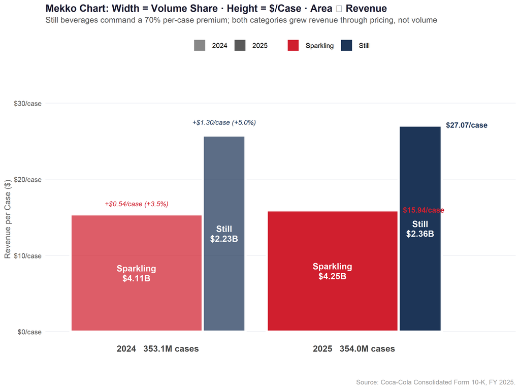

```r
# ── Helper: build one year's Marimekko rectangles ─────────────────
mekko_year <- function(cats, vols, rpc, revs, yr, x_off) {
  shares  <- vols / sum(vols)
  cum_sh  <- cumsum(shares)
  lag_sh  <- c(0, cum_sh[-length(cats)])
  data.frame(
    category = cats,
    year     = as.character(yr),
    volume   = vols,
    rpc      = rpc,
    revenue  = revs,
    xmin     = lag_sh + x_off,
    xmax     = cum_sh + x_off,
    ymin     = 0,
    ymax     = rpc,
    x_mid    = (lag_sh + cum_sh) / 2 + x_off
  )
}

mekko_2024 <- mekko_year(
  cats  = c("Sparkling", "Still"),
  vols  = c(266.7, 86.4),
  rpc   = c(15.40, 25.77),
  revs  = c(4106.1, 2227.2),
  yr    = 2024,
  x_off = 0
)

mekko_2025 <- mekko_year(
  cats  = c("Sparkling", "Still"),
  vols  = c(266.7, 87.3),
  rpc   = c(15.94, 27.07),
  revs  = c(4249.8, 2362.9),
  yr    = 2025,
  x_off = 1.12
)

mekko_all <- bind_rows(mekko_2024, mekko_2025) |>
  mutate(y_mid = ymax / 2)

# ── Revenue growth annotations between years ──────────────────────
delta_df <- data.frame(
  category    = c("Sparkling", "Still"),
  x_arrow     = c(0.755, 1.0),          # right edge of 2024 box
  x_arrowend  = c(0.755 + 1.12, 1.0 + 1.12),  # same col in 2025
  y_arrow     = c(15.40 / 2, 25.77 / 2),
  rev_delta   = c("+3.5% rev\nflat volume", "+6.1% rev\n+1.0% volume"),
  rpc_delta   = c("+$0.54/case", "+$1.30/case")
)

mekko_fills <- c("Sparkling" = COKE_RED, "Still" = NAVY)

ggplot(mekko_all) +
  # ── Main rectangles ──
  geom_rect(aes(xmin = xmin, xmax = xmax,
                ymin = ymin, ymax = ymax,
                fill = category, alpha = year),
            color = "white", linewidth = 1.5) +
  # ── Revenue labels inside boxes ──
  geom_text(aes(x = x_mid, y = y_mid,
                label = paste0(category, "\n$",
                               formatC(revenue / 1000, digits = 2,
                                       format = "f"), "B")),
            color = "white", fontface = "bold",
            size = 4.2, lineheight = 0.95) +
  # ── Revenue/case callouts on right edge (2025 boxes) ──
  geom_text(
    data = filter(mekko_all, year == "2025"),
    aes(x = xmax + 0.025, y = ymax,
        label = paste0("$", rpc, "/case"),
        color = category),
    hjust = 0, vjust = 0.4, size = 3.6, fontface = "bold",
    show.legend = FALSE
  ) +
  # ── Year labels beneath chart ──
  annotate("text",
           x = c(0.50, 1.12 + 0.50), y = -2.2,
           label = c("2024   353.1M cases", "2025   354.0M cases"),
           fontface = "bold", size = 4.2, color = "#444") +
  # ── Price-per-case delta callouts ──
  annotate("text",
           x = c(0.378, 0.878), y = c(16.8, 27.5),
           label = c("+$0.54/case (+3.5%)", "+$1.30/case (+5.0%)"),
           color = c(COKE_RED, NAVY),
           fontface = "italic", size = 3.3) +
  # ── Scales ──
  scale_fill_manual(values = mekko_fills)  +
  scale_color_manual(values = mekko_fills) +
  scale_alpha_manual(values = c("2024" = 0.72, "2025" = 1.0)) +
  scale_y_continuous(
    labels = dollar_format(prefix = "$", suffix = "/case"),
    limits = c(-3.5, 33)
  ) +
  scale_x_continuous(limits = c(-0.02, 2.42)) +
  # ── Labels ──
  labs(
    title    = "Mekko Chart: Width = Volume Share · Height = $/Case · Area \u221d Revenue",
    subtitle = "Still beverages command a 70% per-case premium; both categories grew revenue through pricing, not volume",
    x        = NULL,
    y        = "Revenue per Case ($)",
    caption  = "Source: Coca-Cola Consolidated Form 10-K, FY 2025.",
    fill     = "Category"
  ) +
  theme_coke() +
  theme(
    axis.text.x        = element_blank(),
    axis.ticks.x       = element_blank(),
    panel.grid.major.x = element_blank(),
    legend.position    = "top",
    legend.key.size    = unit(0.8, "cm")
  )
```

## 4 · Question 3 — The $2.4 Billion Bet: What Did COKE Give Up to Buy Its Independence?

On November 7, 2025, Coca-Cola Consolidated executed one of the most consequential deals in its history: it purchased all **18,835,460 shares** of its Common Stock held by a subsidiary of The Coca-Cola Company for approximately **$2.4 billion**, funded with cash on hand and **$1.35 billion in new term loans**. As a result, The Coca-Cola Company went from being a significant equity stakeholder in COKE to owning **zero shares**. The dumbbell charts below show exactly what changed — and what it cost.

```r
# ── Shares outstanding ────────────────────────────────────────────
# Dec 31, 2024 (derived): 56.5M + 18.8M KO buyback + 1.8M repurchase program = 77.1M Common
#                          + 10.0M Class B = 87.1M total
# Dec 31, 2025 (10-K):    56.5M Common + 10.0M Class B = 66.6M total
shares_df <- data.frame(
  period    = factor(c("Dec 31, 2024", "Dec 31, 2025"),
                     levels = c("Dec 31, 2024", "Dec 31, 2025")),
  value     = c(87.1, 66.6),
  pt_label  = c("2024", "2025"),
  val_label = c("87.1M\nshares", "66.6M\nshares\n(\u221220.5M)")
)

# ── Long-term debt ─────────────────────────────────────────────────
# Dec 31, 2024: $1,436.6M | Dec 31, 2025: $2,686.0M (both from 10-K balance sheet)
debt_df <- data.frame(
  period    = factor(c("Dec 31, 2024", "Dec 31, 2025"),
                     levels = c("Dec 31, 2024", "Dec 31, 2025")),
  value     = c(1436.6, 2686.0),
  pt_label  = c("2024", "2025"),
  val_label = c("$1.44B", "$2.69B\n(+87%)")
)

# ── Dumbbell factory function ──────────────────────────────────────
make_dumbbell <- function(df, title, subtitle, xlabel,
                          col_before = GRAY, col_after = COKE_RED,
                          seg_col = COKE_RED) {
  x_before <- df$value[df$period == levels(df$period)[1]]
  x_after  <- df$value[df$period == levels(df$period)[2]]

  ggplot(df, aes(x = value, y = 0)) +
    # Connecting line with arrow
    annotate("segment",
             x = x_before, xend = x_after, y = 0, yend = 0,
             color = seg_col, linewidth = 2.8, alpha = 0.45,
             arrow = arrow(length = unit(0.22, "cm"),
                           type = "closed", ends = "last")) +
    # Dots
    geom_point(aes(color = period), size = 12, show.legend = FALSE) +
    # Year labels inside dots
    geom_text(aes(label = pt_label), color = "white",
              fontface = "bold", size = 3.2, show.legend = FALSE) +
    # Value labels beneath dots
    geom_text(aes(y = -0.13, label = val_label, color = period),
              fontface = "bold", size = 4, lineheight = 0.9,
              show.legend = FALSE) +
    scale_color_manual(
      values = setNames(c(col_before, col_after), levels(df$period))
    ) +
    labs(title = title, subtitle = subtitle, x = xlabel, y = NULL) +
    coord_cartesian(ylim = c(-0.28, 0.14)) +
    theme_coke() +
    theme(
      axis.text.y        = element_blank(),
      axis.ticks.y       = element_blank(),
      panel.grid.major.y = element_blank(),
      panel.grid.major.x = element_line(color = "#eeeeee"),
      axis.line.x        = element_line(color = "#dddddd", linewidth = 0.5)
    )
}

p_shares <- make_dumbbell(
  df         = shares_df,
  title      = "Shares Outstanding Fell 23.5%",
  subtitle   = "18.8M shares retired from KO buyback + 1.8M from ongoing repurchase program",
  xlabel     = "Total Shares Outstanding (millions)",
  col_before = GRAY,
  col_after  = GREEN,
  seg_col    = GREEN
)

p_debt <- make_dumbbell(
  df         = debt_df,
  title      = "Long-Term Debt Rose 87%",
  subtitle   = "$1.35B in new term loans (3-yr $900M + 5-yr $450M) to help fund the buyback",
  xlabel     = "Total Long-Term Debt ($ millions)",
  col_before = GRAY,
  col_after  = COKE_RED,
  seg_col    = COKE_RED
)

# ── FCF payoff callout panel ───────────────────────────────────────
# FCF = Op. Cash Flow ($931.9M) - CapEx ($312.3M) = $619.6M
# Debt / FCF = $2,686M / $619.6M = 4.33 years

fcf_panel <- ggplot() +
  annotate("richtext",
           x = 0.5, y = 0.5,
           label = paste0(
             "<span style='font-size:12pt;'>",
             "At 2025 free cash flow of ",
             "<b style='color:", COKE_RED, ";'>$619.6M/year</b>",
             " (Op. Cash Flow \u2212 CapEx), ",
             "it would take approximately ",
             "<b style='color:", COKE_RED, ";'>4.3 years</b> ",
             "to fully repay the $2.69B long-term debt.",
             "</span><br><br>",
             "<span style='font-size:10pt; color:#555;'>",
             "The underlying business is generating record cash \u2014 ",
             "the debt load is heavy but manageable.",
             "</span>"
           ),
           fill = "#fff8f8", label.color = "#f5c6c6",
           label.r = unit(6, "pt"),
           label.padding = unit(c(12, 16, 12, 16), "pt"),
           hjust = 0.5, vjust = 0.5,
           size = 4, lineheight = 1.5,
           width = unit(0.88, "npc")) +
  xlim(0, 1) + ylim(0, 1) +
  theme_void() +
  theme(plot.background = element_rect(fill = "white", color = NA))

# ── Combine with patchwork ─────────────────────────────────────────
(p_shares / p_debt / fcf_panel) +
  plot_layout(heights = c(1, 1, 0.55)) +
  plot_annotation(
    title    = "The $2.4 Billion Independence Trade-Off",
    subtitle = "KO's equity stake eliminated in Nov 2025 \u2014 fewer shares outstanding, significantly more debt",
    caption  = paste0(
      "Source: Coca-Cola Consolidated Form 10-K, FY 2025.\n",
      "Shares Dec 31, 2024 derived from Jan 30, 2026 filing plus 2025 buyback activity (18.8M + 1.8M)."
    ),
    theme = theme(
      plot.title    = element_text(face = "bold", size = 17, color = DKBG,
                                   margin = margin(b = 4)),
      plot.subtitle = element_text(color = "#555555", size = 12,
                                   margin = margin(b = 16)),
      plot.caption  = element_text(color = "#999999", size = 9,
                                   margin = margin(t = 12)),
      plot.background = element_rect(fill = "white", color = NA)
    )
  )
```

[figure not shown]

**Key Finding:** COKE's November 2025 buyback of The Coca-Cola Company's entire equity stake was a deliberate trade-off: **more control, more debt**. Shares outstanding fell 23.5% — from 87.1 million to 66.6 million — which is mathematically favorable for remaining shareholders (each share represents a larger slice of the company). The price was a near-doubling of long-term debt, from $1.44 billion to $2.69 billion (+87%). Yet the underlying cash engine is strong enough to service it: at 2025 free cash flow of $619.6 million, the implied payback period is roughly **4.3 years**. The deal is best understood not as financial distress, but as a calculated leveraged buyout of COKE's own independence from its largest shareholder.

## 5 · Conclusion

Taken together, the three analyses paint a coherent portrait of Coca-Cola Consolidated at an inflection point. The company's **top-line momentum is real**: net sales grew 8.6% over three years and operating income hit a record $950.7 million in 2025. But the story beneath the headline numbers is more nuanced.

Question 1 revealed that GAAP net income is a poor lens for this business — a single non-cash mark-to-market charge ($131.9 million) accounted for 35% of the drop from operating income to net income in 2025, while operating cash flow quietly set a three-year high of $931.9 million. **Cash generation, not GAAP earnings, is the right scorecard here.**

Question 2 showed that volume growth is essentially flat — COKE is not selling meaningfully more cases, it is charging more per case. Still beverages already command a 70% per-case premium over Sparkling and that gap is widening, suggesting consumers are trading up and COKE has meaningful pricing power in the higher-margin still category (energy drinks, protein shakes, enhanced water). **Revenue growth is a pricing story, not a volume story.**

Question 3 explained why this cash-generating ability matters so much right now: COKE took on $1.35 billion in new debt to buy back every share held by The Coca-Cola Company, permanently ending a corporate relationship that defined the bottler for decades. The balance sheet is significantly more leveraged, but with free cash flow of $619.6 million per year, the implied payback is manageable. **COKE bet its balance sheet on its own future — and the operating fundamentals suggest that bet is well-placed.**

Source: Coca-Cola Consolidated, Inc. Form 10-K, Fiscal Year Ended December 31, 2025 (filed with the U.S. Securities and Exchange Commission). All figures in USD millions unless otherwise noted. Analysis prepared by Tyler Jones, BANA 4137, Spring 2026.